# spaDesign: a simulation-based statistical framework to facilitate spatial transcriptomics experimental design

## Introduction

`spaDesign` is a simulation-based statistical framework to facilitate the design of high-throughput spatial transcriptomics experiment. It consists of four steps, feature selection, parameter estimation, data simulation and performance/power evaluation. This vignette will demonstrate the workflow with an demo data.

## Pre-requirement

The package uses `SpaGCN` (Hu et al. 2021) for spatial domain identification. To use our workflow smoothly, it is highly recommended to create a conda environment for `SpaGCN`, and then install `SpaGCN` using `pip3 install --user SpaGCN`.

Note1: the following command lines are for the terminal

Note2: in the example code, a particular python version was specified. Users may choose their preferred python version, no need to be 3.8.8. Yet according to our experience, we recommend python 3.8 and up due to the dependence issue. For detailed information regarding the installation of SpaGCN, please refer to https://github.com/jianhuupenn/SpaGCN/blob/master/tutorial/tutorial.ipynb

```python
# open the terminal, create a conda environment called test_spagcn

conda create -n spagcn python=3.8.8

# actiave the conda environment
conda activate spagcn

# install SpaGCN under the activated conda environment
pip3 install --user spagcn
```

The performance evaluation function needs the path to the conda environment. To locate the path, we can use the `conda_list` function in `reticulate` R package after installing `SpaGCN`.

```r
# Under R, locate the conda environment
library(reticulate)
conda_list()

# conda_list() may show something like /users/username/.conda/envs/spagcn/bin/python
# specify the path to the conda environment
conda_env_path <- '/users/username/.conda/envs/spagcn/'
```

## Note

The results below are provided for the illustration purpose and should not be considered as real results. They are run under settings for quick testing of the functions and knitting of the R vignette. We recommend users to use sufficient number of MCMC iterations for the real data analysis.

## Get started

To get started, please load the `spaDesign` package

```r
library(spaDesign)
```

Once loaded the package, we can perform power analysis with the package-embedded example data, which was created based on the human brain DLPFC data (Maynard et al. 2021). The original human brain DLPFC data contains the gene expression for more than30,000 genes across 3,611 annotated spots. The example data is a subset of the original data, containing gene expression for 73 genes across 3,611 spots.

## Example spatial transcriptomics data

```r
str(exampleData)
```

```
## List of 2
##  $ count:Formal class 'dgCMatrix' [package "Matrix"] with 6 slots
##   .. ..@ i       : int [1:248275] 0 1 2 3 4 5 6 7 8 9 ...
##   .. ..@ p       : int [1:3612] 0 69 127 191 262 333 405 476 548 621 ...
##   .. ..@ Dim     : int [1:2] 73 3611
##   .. ..@ Dimnames:List of 2
##   .. .. ..$ : chr [1:73] "CAMK2N1" "STMN1" "RPS8" "ATP1B1" ...
##   .. .. ..$ : chr [1:3611] "AAACAAGTATCTCCCA-1" "AAACAATCTACTAGCA-1" "AAACACCAATAACTGC-1" "AAACAGAGCGACTCCT-1" ...
##   .. ..@ x       : num [1:248275] 10 11 7 16 18 12 9 15 11 24 ...
##   .. ..@ factors : list()
##  $ loc  :'data.frame':   3611 obs. of  3 variables:
##   ..$ x     : int [1:3611] 8468 2807 9505 4151 7583 8064 11194 9783 7875 7473 ...
##   ..$ y     : int [1:3611] 9791 5769 4068 9271 3393 3665 5709 9437 10690 4703 ...
##   ..$ domain: chr [1:3611] "Layer3" "Layer1" "WM" "Layer3" ...
```

## Create a spaDesign object

Most functions in the package takes a `spaDesign` object as the input, which is an S4 object. To create this object, two information is required, one is the gene expression count matrix (**count_matrix**) and the other is a data frame containing the spots coordinates and domain annotation information (**loc**).

```r
DATA <- createSpaDesignObject(count_matrix = exampleData$count, loc = exampleData$loc )
DATA
```

```
## class: spaDesign
## Reference dim: 73 3611
## Reference rownames (first 5): CAMK2N1, STMN1, RPS8, ATP1B1, VSNL1 , ...
## Reference colnames (first 5): AAACAAGTATCTCCCA-1, AAACAATCTACTAGCA-1, AAACACCAATAACTGC-1, AAACAGAGCGACTCCT-1, AAACAGCTTTCAGAAG-1 , ...
## refcolData names: x, y, domain
## Simulated Count dim: 0 0
## Simulated Count rownames (first 5): NULL
## Simulated Count colnames (first 5): NULL
## simcolData names:
```

## Feature selection

In this step, genes with large absolute fold change will be selected as domain-informative features. Users need to specify three key arguments:

- `logfc_cutoff` : the threshold for log fold change, used to select genes
- `mean_in_cutoff` : threshold for mean expression of within-domain spots(log-transformed)
- `max_num_gene`: the maximum number of genes that can be selected for each spatial domain

```r
DATA <- selectFeatures(DATA, logfc_cutoff = 0.7, mean_in_cutoff = 1.8, max_num_gene = 10)
```

## Parameter estimation

### Poisson Gaussian process model

In this step, we can model the spatial expression pattern of the selected domain-informative with Poisson Gaussian process model. Note that in the example code we use a small number of MCMC iteration (**n_iter**) and burn-in (**n_burn**) for demonstration purpose. In real practice, we recommend larger number of iterations to ensure algorithm convergence.

```r
DATA <- estimateParamsPoissonGP(DATA, n_iter = 1000, n_burn = 500)
```

### Fisher Gaussian kernel mixture model

The spatial distribution of domain spots is be modeled via the Fisher Gaussian kernel mixture model (Mukhopadhyay, Li, and Dunson 2020)

```r
DATA <- estimateParamsFG(DATA, n_iter = 2000)
```

## Power analysis

With the estimated parameters, users can now assess the performance of spatial domain identification by simulating a range of datasets and calculating the normalized mutual information (NMI) metric under various scenarios.

### Impact of effect size and sequencing depth

By specifying a range of effect size scaling factors and sequencing depth scaling factors, users can evaluate how variations in these factors impact the detection of spatial domains by utilizing the `powerAnalysisEffectSize` function. In particular, users need to specify the following arguments:

- `es_range` : a numeric vector of effect sizes (relative to pilot data)
- `seq_depth_range` : a numeric vector containing the total sequencing depths for the simulated data(relative to pilot data)
- `n_rep`: the number of replications for each simulation scenario
- `conda_env_path` : the path to the conda environment for spaGCN

```r
es_range <- c(0.5, 3)
seq_depth_range <- c(1, 3, 5)
n_rep <-5

rst1 <- powerAnalysisEffectSize(DATA, es_range, seq_depth_range, n_rep, conda_env_path)
rst1
```

```
##    seq_depth effect_size total_counts       NMI
## 1          1         0.5       896140 0.8495194
## 2          3         0.5      2699529 0.8400758
## 3          5         0.5      4505646 0.8506999
## 4          1         3.0       896161 0.4583229
## 5          3         3.0      2696126 0.6861490
## 6          5         3.0      4499456 0.6702626
## 7          1         0.5       914427 0.8111064
## 8          3         0.5      2741318 0.8545592
## 9          5         0.5      4569249 0.8304972
## 10         1         3.0       915266 0.4331076
## 11         3         3.0      2741920 0.7128105
## 12         5         3.0      4568165 0.6668448
## 13         1         0.5       908698 0.8573222
## 14         3         0.5      2707423 0.8550856
```

[output cut: 16 more lines]

Users can plot the results

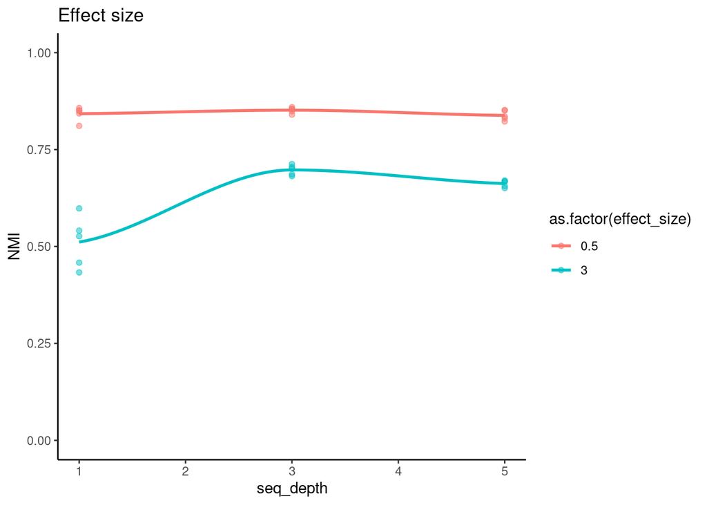

```r
library(ggplot2)

ggplot(rst1, aes(x = seq_depth, y = NMI, color = as.factor(effect_size))) +
  geom_point(alpha = 0.5) +  # Add points with transparency
  geom_smooth(method = "loess", se = FALSE, span = 0.9) +
  ggtitle('Effect size') +
  theme_classic() +
  ylim(0, 1) +
  xlab('seq_depth')
```

### Impact of the spatial pattern

By specifying the range of proportions of genes with undisturbed patterns and sequencing depth scaling factors, users can evaluate how variations in these factors impact the detection of spatial domains using the `powerAnalysisSpatial` function. Users need to specify the following arguments:

- `prop_range` : a numeric vector indicating the proportions of genes with undisturbed spatial pattern
- `seq_depth_range` : a numeric vector containing the total sequencing depths for the simulated data(relative to pilot data)
- `n_rep`: the number of replications for each simulation scenario
- `conda_env_path` : the path to the conda environment for spaGCN

```r
seq_depth_range <- c(1, 3, 5)
prop_range <- c(0.2, 0.8)
n_rep <-5

rst2 <- powerAnalysisSpatial(DATA, prop_range, seq_depth_range, n_rep, conda_env_path)
```

```r
rst2
```

```
##    seq_depth prop total_counts       NMI
## 1          1  0.2       876021 0.3372897
## 2          3  0.2      2634562 0.4046901
## 3          5  0.2      4398345 0.4470096
## 4          1  0.8       896935 0.5185192
## 5          3  0.8      2697446 0.6573287
## 6          5  0.8      4503280 0.6040459
## 7          1  0.2       893484 0.3344074
## 8          3  0.2      2678004 0.4021134
## 9          5  0.2      4463237 0.4237027
## 10         1  0.8       914746 0.6715849
## 11         3  0.8      2741816 0.6996802
## 12         5  0.8      4569409 0.6577804
## 13         1  0.2       886893 0.3184059
## 14         3  0.2      2645561 0.4790163
```

[output cut: 16 more lines]

Users can plot the results:

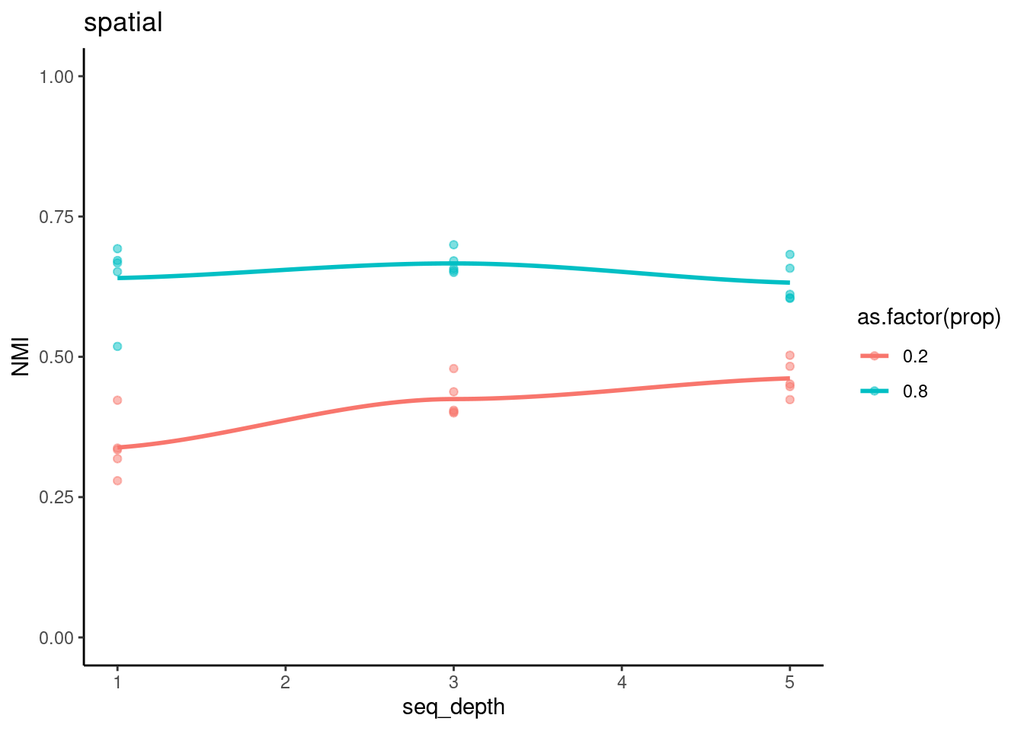

```r
ggplot(rst2, aes(x = seq_depth, y = NMI, color = as.factor(prop))) +
  geom_point(alpha = 0.5) +  # Add points with transparency
  geom_smooth(method = "loess", se = FALSE, span = 0.9) +
  ggtitle('spatial') +
  theme_classic() +
  ylim(0, 1) +
  xlab('seq_depth')
```

## Advanced use

The package provides separate functions for simulating a single spatial data and calculating the NMI for the simulated data.

### Simulate data with specified effect size and sequencing depths scaling factor

Users can simulate data with modified sequencing depth and effect size by specifying a sequencing depth and effect size (relative to pilot data). The following key arguments need to be specified:

- `seq_depth` : a numeric value, indicating the total sequencing depth for the simulated data(relative to pilot data)
- `effect_size` : a numeric value, indicating the effect size for the simulated data (relative to pilot data)
- `SEED`: random seed, set for reproducibility

```r
DATA1 <- simulateDataEffectSize(DATA, seq_depth = 1, effect_size = 1, SEED = 1)
```

Then users can evaluate spatial domain identification performance.

```r
DATA1 <- evaluatePower(DATA1, conda_env_path)
DATA1@NMI
```

### Data with dispersed spatial pattern

Users can first simulate a data with nosier spatial pattern. And the key arguments are:

- `seq_depth` : a numeric value, indicating the total sequencing depth for the simulated data(relative to pilot data)
- `SIGMA` : a numeric value, indicating the spatial noise level. Larger `SIGMA`, noisier the data *`prop` : a numeric value, denoting the proportion of genes with undisturbed spatial pattern
- `SEED`: random seed, set for reproducibility

```r
DATA2 <- simulateDataSpatial(DATA, seq_depth = 1, SIGMA = 1, SEED =1, prop = 0.8)
```

Then users can evaluate spatial domain identification performance.

```r
DATA2 <- evaluatePower(DATA2, conda_env_path)
DATA2@NMI
```

## References

Hu, Jian, Xiangjie Li, Kyle Coleman, Amelia Schroeder, Nan Ma, David J Irwin, Edward B Lee, Russell T Shinohara, and Mingyao Li. 2021. “SpaGCN: Integrating Gene Expression, Spatial Location and Histology to Identify Spatial Domains and Spatially Variable Genes by Graph Convolutional Network.” *Nature Methods* 18 (11): 1342–51.

Maynard, Kristen R, Leonardo Collado-Torres, Lukas M Weber, Cedric Uytingco, Brianna K Barry, Stephen R Williams, Joseph L Catallini, et al. 2021. “Transcriptome-Scale Spatial Gene Expression in the Human Dorsolateral Prefrontal Cortex.” *Nature Neuroscience* 24 (3): 425–36.

Mukhopadhyay, Minerva, Didong Li, and David B Dunson. 2020. “Estimating Densities with Non-Linear Support by Using Fisher–Gaussian Kernels.” *Journal of the Royal Statistical Society Series B: Statistical Methodology* 82 (5): 1249–71.